# Proyecto Predicción de Estado Civil

Yanelly Nobrega CI V-22785031 - Wilmer Prieto CI V-21468564

15 de mayo de 2016

## Explicación del Problema

- Este proyecto está basado en una competencia de Kaggle
- El objetivo es buscar un algoritmo que permita generar un modelo que prediga de manera eficiente el estado civil de una pareja dado un set de datos.
- Todos estos datos pasarán por un pre-procesamiento y finalmente para la generación de los modelos se utilizarán los algoritmos Árbol de Decisión, K-Vecinos y Reglas de Clasificación.

## Instalación de paquetes necesarios

```r
#install.packages('rpart.plot');
#install.packages('rpart');
#install.packages('pROC')
#install.packages('RWeka')
#install.packages('class')
library('rpart')
library('rpart.plot')
library('RWeka')
library('class')
library('pROC')
```

## Carga del set de datos

- Este archivo contiene los datos relacionados al estado civil de una pareja, los cuales serán utilizados para implementar y evaluar los modelos anteriormente mencionados, y de esta forma poder elegir el mejor modelo para la predicción que se desea realizar.

```r
set.seed(23462)
marriageData <- read.csv("marriageData.csv")
```

```r
#Descripcion de la data
#ID = Identificador unico para cada registro(paerja) del dataset
#GAGE = Edad de la Mujer
#BAJE = Edad del Hombre
#GP =
#BP =
#AINCOME = Sueldo Anual en dolares percibido por la pareja
```

## Preprocesamiento de la data

*Numeración de las columnas “GP”, “BP” y “STATUS”

```r
marriageData$GP <- as.character(marriageData$GP)
marriageData$GP[grepl("A", marriageData$GP, ignore.case = TRUE)] <- 0
marriageData$GP[grepl("B", marriageData$GP, ignore.case = TRUE)] <- 1
marriageData$GP <- as.numeric(marriageData$GP)

marriageData$BP <- as.character(marriageData$BP)
marriageData$BP[grepl("A", marriageData$BP, ignore.case = TRUE)] <- 0
marriageData$BP[grepl("B", marriageData$BP, ignore.case = TRUE)] <- 1
marriageData$BP <- as.numeric(marriageData$BP)

marriageData$STATUS <- as.character(marriageData$STATUS)
marriageData$STATUS[grepl("Married", marriageData$STATUS, ignore.case = TRUE)] <- 1
marriageData$STATUS[grepl("Separated", marriageData$STATUS, ignore.case = TRUE)] <- 2
marriageData$STATUS[grepl("Divorced", marriageData$STATUS, ignore.case = TRUE)] <- 3
marriageData$STATUS <- as.numeric(marriageData$STATUS)
```

## Preprocesamiento de la data

- Se eliminan las columnas “ID” y “AINCOME”
- Creación de nueva columna almacenando las diferencias de edades de la pareja.

```r
marriageData$ID <- NULL
marriageData$AINCOME <- NULL

marriageData$GAGE <- as.numeric(marriageData$GAGE)
marriageData$BAGE <- as.numeric(marriageData$BAGE)

marriageData$dAge <- 0

for(i in 1:nrow(marriageData)){
  marriageData$dAge[i] <- abs(marriageData$GAGE[i] - marriageData$BAGE[i])
}

marriageData$GAGE <- NULL
marriageData$BAGE <- NULL
```

## Muestreo

Dado que se tienen posibles valores (1-3) para la variable que se desea predecir “STATUS”, se realiza un muestreo estratificado para asegurar que el mismo sea proporcional y exista un equilibrio en las muestras de entrenamiento y prueba.

```r
for (i in 1:3) {

  aux <- marriageData[marriageData$STATUS == i, ]
  muestraAux <- sample(nrow(aux), nrow(aux) * 0.8, replace = FALSE , prob=NULL)
  trainAux <- aux[muestraAux,]
  testAux <- aux[-muestraAux,]
  if(i == 1){
    training <- trainAux
    testing <- testAux
  }else{
    training <- merge(training, trainAux, all = TRUE)
    testing <- merge(testing, testAux, all = TRUE)
  }
}
```

## Modelos utilizados

- A continuación se mostrará todo el procedimiento realizado para evaluar la calidad de los modelos basados en **Arboles de desición, k vecinos mas cercanos y reglas de clasificación**, entorno a la predicción del estado civil de una pareja.
- Se decidió utilizar estos métodos de clasificación porque fueron los estudiados en la materia de Minería de Datos y de los cuales se tenía mayor conocimiento a la hora de implementar la solución.

## Arbol de desición

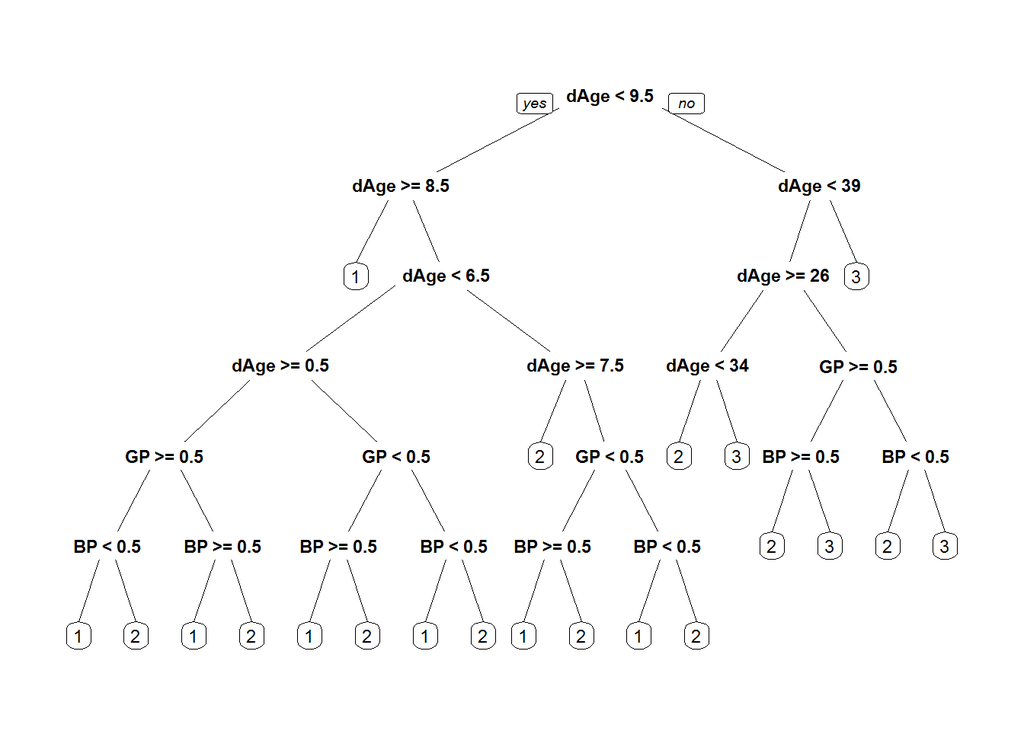

```r
tree <- rpart(STATUS ~ ., data = training , method ="class")
rpart.plot(tree)
```

```r
predictArbol <- predict(tree, testing, type = "class")

#Matriz de confusión
matrizConfA<-table(testing$STATUS,predictArbol)
matrizConfA
```

```
##    predictArbol
##      1  2  3
##   1 45  1  0
##   2  1 69  7
##   3  0  6 21
```

```r
#Tasa de Aciertos
AciertosA <- sum(diag(matrizConfA)) / nrow(testing)
AciertosA
```

```
## [1] 0.9
```

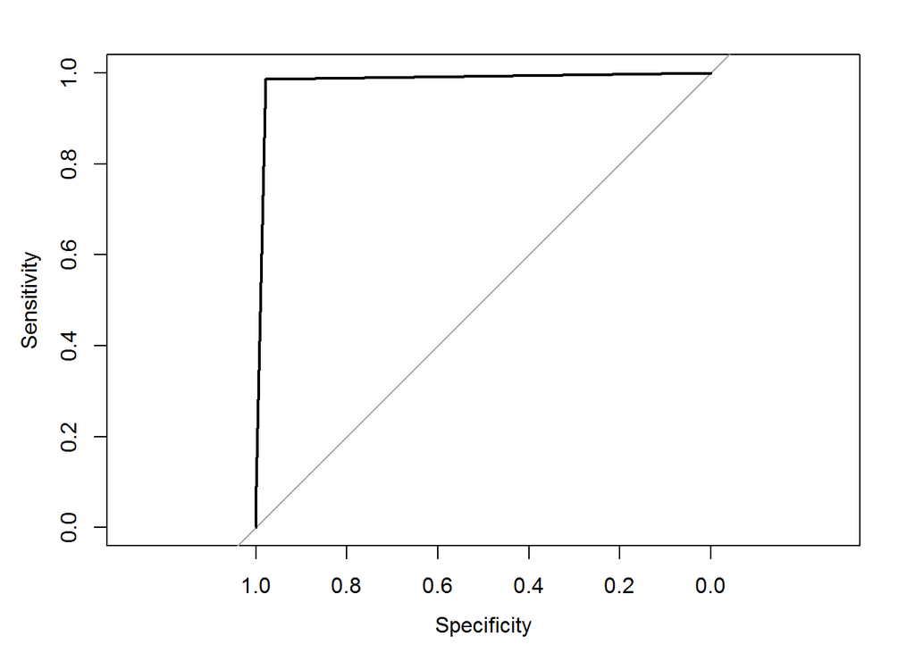

```
##
## Call:
## roc.default(response = testing$STATUS, predictor = as.numeric(predictArbol),     levels = c(1, 2, 3))
##
## Data: as.numeric(predictArbol) in 46 controls (testing$STATUS 1) < 77 cases (testing$STATUS 2).
## Area under the curve: 0.9836
```

```r
#ROC
rArbol <- roc(testing$STATUS, as.numeric(predictArbol), levels=c(1,2,3))
plot(rArbol)
```

## k-vecinos

```r
trainingLabels <- training$STATUS
testingLabels <- testing$STATUS

trainingClasificationRules <- training
testingClasificationRules <- testing
training[,"STATUS"] <- NULL
testing[,"STATUS"] <- NULL

predictKnn <- knn(train = training, test = testing, cl = trainingLabels, k=28)

#Matriz de confusión
matrizConfusionKnn <- table(testingLabels, predictKnn)
matrizConfusionKnn
```

```
##              predictKnn
## testingLabels  1  2  3
##             1 16 30  0
##             2 13 47 17
##             3  0 18  9
```

```r
#Tasa de Aciertos
AciertosKnn <- sum(diag(matrizConfusionKnn)) / nrow(testing)
AciertosKnn
```

```
## [1] 0.48
```

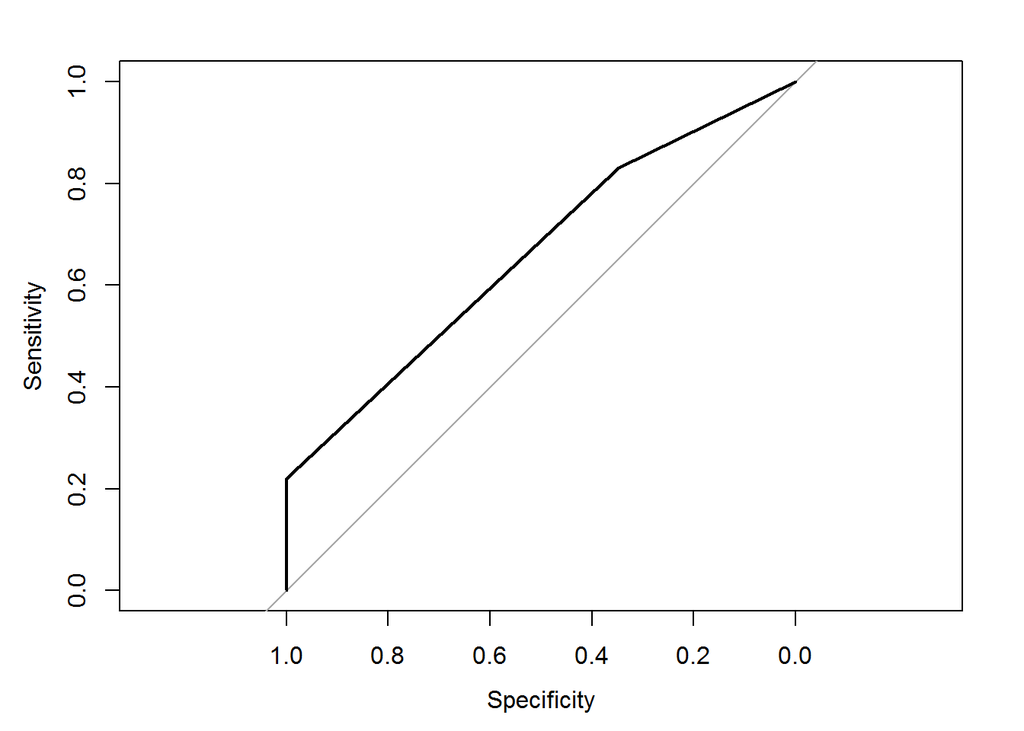

```
##
## Call:
## roc.default(response = testingLabels, predictor = as.numeric(predictKnn),     levels = c(1, 2, 3))
##
## Data: as.numeric(predictKnn) in 46 controls (testingLabels 1) < 77 cases (testingLabels 2).
## Area under the curve: 0.6615
```

```r
#ROC
rKnn <- roc(testingLabels, as.numeric(predictKnn), levels=c(1,2,3))
plot(rKnn)
```

## Reglas de clasificación

```r
trainingClasificationRules$STATUS <- as.factor(trainingClasificationRules$STATUS)
testingClasificationRules$STATUS <- as.factor(testingClasificationRules$STATUS)

#Aplicacion de la funcion JRip
rules <- JRip(formula = STATUS ~ ., data = trainingClasificationRules)

predictClass <- predict(rules, testingClasificationRules, type = "class")

#Matriz de confusión
matrizConfusionClass <- table(testingClasificationRules$STATUS, predictClass)
matrizConfusionClass
```

```
##    predictClass
##      1  2  3
##   1 46  0  0
##   2  0 77  0
##   3  0  0 27
```

```r
#Tasa de Aciertos
AciertosClass <-  sum(diag(matrizConfusionClass)) / nrow(testing)
AciertosClass
```

```
## [1] 1
```

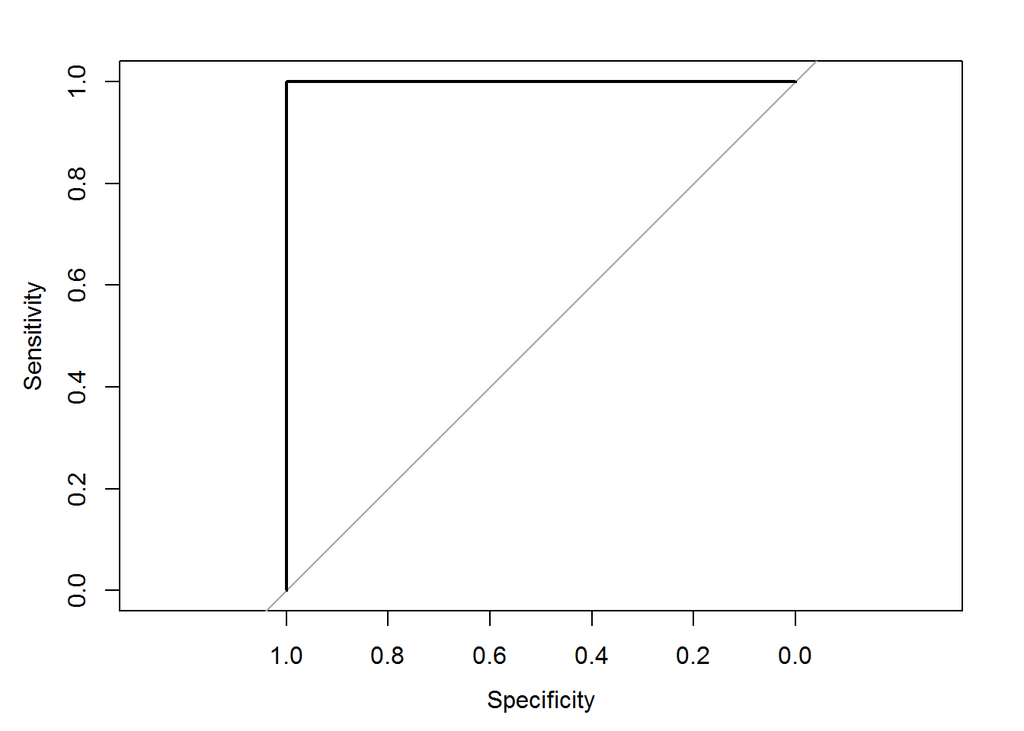

```
##
## Call:
## roc.default(response = testingLabels, predictor = as.numeric(predictClass),     levels = c(1, 2, 3))
##
## Data: as.numeric(predictClass) in 46 controls (testingLabels 1) < 77 cases (testingLabels 2).
## Area under the curve: 1
```

```r
#ROC
rClass <- roc(testingLabels, as.numeric(predictClass), levels=c(1,2,3))
plot(rClass)
```